# Cambios en las interrupciones legales del embarazo en Ciudad de México a partir de la pandemia de SARS-CoV-2

Rodrigo Zepeda

rodrigo.zepeda@imss.gob.mx

## Introducción

La pandemia por SARS-CoV-2 ha resultado en interrupciones a la prestación de algunos servicios de salud en México Doubova et al. (2021). Al inicio de la misma varios actores internacionales alzaron la voz para evitar que la respuesta a la pandemia interfiriera con la prestación de este servicio de salud Turret et al. (2020) Todd-Gher and Shah (2020). El **objetivo** de este análisis es estudiar si hubo un **cambio en el número de ILE realizados después del inicio de la pandemia por SARS-CoV-2**.

### Descripción de la base

Las variables contenidas en la base son:

| Variable | Descripción |
| --- | --- |
| año | Año en que se realizó el procedimiento |
| mes | Mes en que se realizó el procedimiento |
| clues_hospital | Clave Única de Establecimientos de Salud (CLUES) |
| fingreso | Fecha de Interrupción Legal del Embarazo |
| autoref | Especificar si la paciente es referida de otra unidad o acude directamente |
| edocivil_descripcion | Estado civil |
| edad | Edad cumplida en años |
| desc_derechohab | Especificar la institución que otorga la derechohabiencia |
| nivel_edu | Último nivel escolar acreditado |
| ocupacion | Ocupación |
| religion | Religión |
| parentesco | Parentesco del responsable con la paciente solamente para menores de edad obligatorio |
| entidad | Entidad de residencia |
| alc_o_municipio | Alcaldía o municipio de residencia |
| menarca | Edad de la primera menstruación |
| fsexual | Edad de inicio de vida sexual activa |
| fmenstrua | Fecha de la última menstruación |
| sememb | Semanas de embarazo por fecha de última menstruación |
| nhijos | Número de hijos |
| gesta | Número de embarazos (Incluyendo abortos) |
| naborto | Número de abortos (Sin contar ILE) |
| npartos | Número de nacimientos por vía vaginal |
| ncesarea | Número de cesáreas |
| nile | Número de Interrupciones Legales del Embarazo previas al procedimiento actual |
| consejeria | Especificar si la paciente recibió consejería sobre la ILE |
| anticonceptivo | Especificar si la paciente utiliza de forma habitual método anticonceptivo |
| c_fecha | Fecha de primera valoración o atención |
| c_num | Número de consultas previas al ILE |
| motiles | Motivo por el cual se desea la interrupción del embarazo |
| h_fingreso | En caso de hospitalización, fecha de ingreso |
| h_fegreso | En caso de hospitalización, fecha de egreso |
| desc_servicio | Servicio en el que se otorgó la interrupción |
| p_semgest | Semanas de gestación por USG |
| p_diasgesta | Días de gestación por USG |
| p_consent | Se requisitó y firmo el consentimiento informado |
| s_complica | Se presentaron complicaciones por el procedimiento |
| c_dolor | Se presentó dolor posterior al procedimiento |
| tanalgesico | Se prescribe medicación analgeésica |
| panticoncep | Método anticonceptivo proporcionado post evento obstétrico |
| fecha_cierre | Fecha de cierre del procedimiento de ILE |
| resultado_ile | Resultado del procedimiento de ILE |

## Análisis exploratorio con código

La distribución de edad por año está dada por la siguiente tabla:

| año | Media | SD | Mediana | Mínimo | Máximo |
| --- | --- | --- | --- | --- | --- |
| 2016 | 25.57614 | 6.304041 | 24 | 11 | 52 |
| 2017 | 25.75304 | 6.293907 | 25 | 11 | 50 |
| 2018 | 25.72321 | 6.242792 | 25 | 12 | 52 |
| 2019 | 25.81031 | 6.280275 | 25 | 11 | 53 |
| 2020 | 26.02769 | 6.183470 | 25 | 12 | 50 |
| 2021 | 26.21708 | 6.141621 | 25 | 12 | 56 |
| 2022 | 26.24176 | 6.226918 | 25 | 12 | 47 |

donde la edad mínima registrada fue de 11 mientras que la máxima fue de: 56.

Se realizó un histograma con $25$ rectángulos y un ajuste por densidad kernel con núcleo gaussiano para determinar la forma de la distribución de los datos por año. Ésta es como sigue:

[figure not shown]

La cantidad de interrupciones elaboradas pre y post pandemia parece haber disminuido más de lo usual:

| Año | Total de ILE registradas |
| --- | --- |
| 2016 | 18086 |
| 2017 | 17598 |
| 2018 | 17179 |
| 2019 | 15251 |
| 2020 | 11269 |
| 2021 | 12295 |
| 2022 | 6341 |

Si graficamos los totales por día podemos obtener una mejor idea del comportamiento de la serie. Hemos agregado un suavizamiento mediante *splines* para distinguir la tendencia

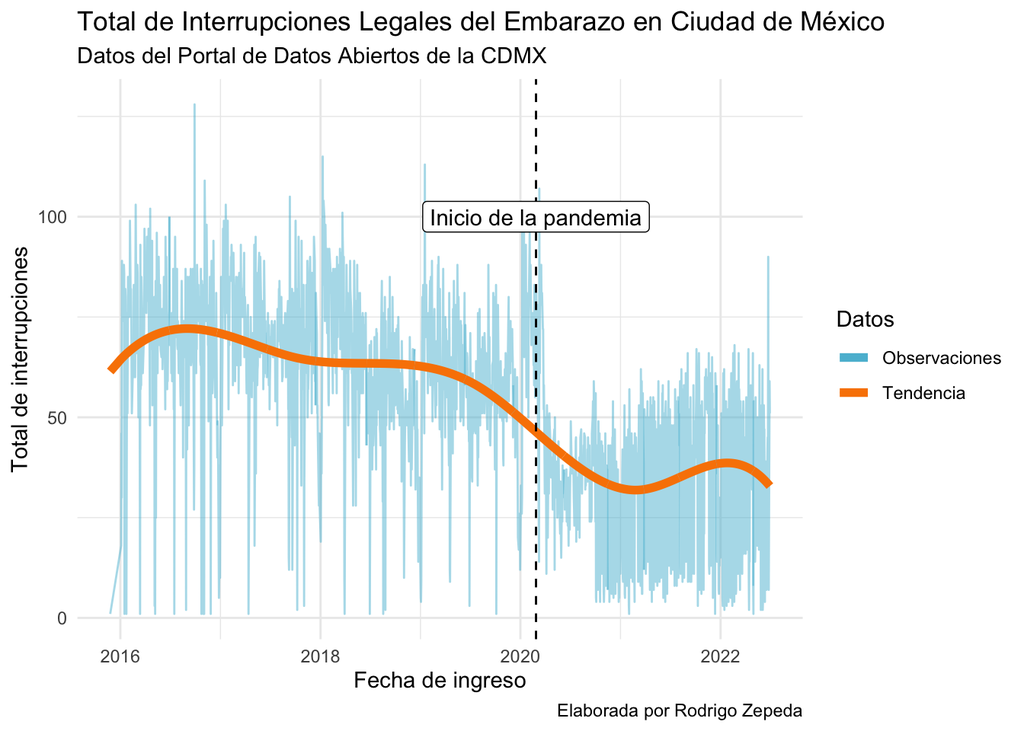

La siguiente tabla muestra la composición sociodemográfica de las personas que llegaban antes y después de la pandemia por entidad (la cual inició el 27 de febrero 2020 de acuerdo con Suárez et al. (2020)). Podemos notar que no existen diferencias relevantes en cuanto a quienes asistieron a la prestación del servicio (es decir, legalizar en Oaxaca e Hidalgo no parece haber influido en el porcentaje registrado por entidad en CDMX).

| Entidad | Pre pandemia | Pandemia |
| --- | --- | --- |
| CIUDAD DE MEXICO | 0.6315736 | 0.6429044 |
| ESTADO DE MEXICO | 0.3172255 | 0.3204601 |
| PUEBLA | 0.0076057 | 0.0062468 |
| HIDALGO | 0.0076635 | 0.0049974 |
| MORELOS | 0.0049885 | 0.0038583 |
| QUERETARO | 0.0039908 | 0.0031234 |
| JALISCO | 0.0038751 | 0.0024620 |
| GUANAJUATO | 0.0025738 | 0.0022047 |
| VERACRUZ | 0.0033690 | 0.0019108 |
| MICHOACAN | 0.0027762 | 0.0018740 |
| TLAXCALA | 0.0023135 | 0.0016903 |
| GUERRERO | 0.0017207 | 0.0012126 |
| QUINTANA ROO | 0.0010411 | 0.0009186 |
| SAN LUIS POTOSI | 0.0009543 | 0.0008819 |
| NUEVO LEON | 0.0008820 | 0.0008452 |
| BAJA CALIFORNIA | 0.0003326 | 0.0005879 |
| OAXACA | 0.0019231 | 0.0005879 |
| TAMAULIPAS | 0.0003615 | 0.0004777 |
| AGUASCALIENTES | 0.0007085 | 0.0004409 |
| ZACATECAS | 0.0005784 | 0.0003675 |
| YUCATAN | 0.0003036 | 0.0002940 |
| NAYARIT | 0.0004193 | 0.0002572 |
| SONORA | 0.0002314 | 0.0002572 |
| CHIHUAHUA | 0.0004482 | 0.0002205 |
| CHIAPAS | 0.0004772 | 0.0001837 |
| COAHUILA | 0.0002458 | 0.0001837 |
| DURANGO | 0.0003036 | 0.0001837 |
| TABASCO | 0.0003759 | 0.0001837 |
| BAJA CALIFORNIA SUR | 0.0002458 | 0.0001102 |
| SINALOA | 0.0001880 | 0.0000367 |

Si bien de la asociación entre pandemia y reducción de casos no podemos concluir causalidad (es decir no podemos concluir que la pandemia redujo los casos) sí podemos concluir que hay una asociación entre el inicio de la pandemia y los casos y que dicha asociación no parece ser explicada por las variables sociales. Hacen falta más análisis con ecuaciones estructurales para deducir la causalidad.

# Referencias

Doubova, Svetlana V, Hannah H Leslie, Margaret E Kruk, Ricardo Pérez-Cuevas, and Catherine Arsenault. 2021. “Disruption in Essential Health Services in Mexico During COVID-19: An Interrupted Time Series Analysis of Health Information System Data.” *BMJ Global Health* 6 (9): e006204.

Suárez, Vı́ctor, M Suarez Quezada, S Oros Ruiz, and E Ronquillo De Jesús. 2020. “Epidemiologı́a de COVID-19 En méxico: Del 27 de Febrero Al 30 de Abril de 2020.” *Revista Clı́nica Española* 220 (8): 463–71.

Todd-Gher, Jaime, and Payal K Shah. 2020. “Abortion in the Context of COVID-19: A Human Rights Imperative.” *Sexual and Reproductive Health Matters* 28 (1): 1758394.

Turret, Erica, Sara Tannenbaum, Blake Shultz, and Katherine Kraschel. 2020. “COVID-19 Does Not Change the Right to Abortion.” *Health Affairs* 17.